# Agent-Based_Models

Eric Dougherty & Dana Seidel

December 17, 2017

We have seen how functions can be used to simulate movement, whether completely random or empirically-based. We have implemented these functions in a behavioral framework, such that a change in the internal state of the animal induces a different type of movement. In order to creat an agent-based simulation model, however, our goal will be to create a landscape with which our agents interact. Depending on the nature of that interaction, we can dictate the manner by which they move! Ultimately, this could be used to simulate all sorts of different things, but we will work towards implementing a disease-related model such that certain conditions lead to the transmission of infection as simulated agents move across a landscape.

Let’s begin with creating a landscape! Just as in the real world, landscapes can take many different forms, ranging from completely homogenous planes to a highly heterogeneous surface. Many landscapes will be completely homogeneous with respect to some variables, say elevation, while being entirely hetergeneous in others, like vegetation. Because we are creating the landscape, we can choose which variables are important and which are functionally irrelevant to our particular purposes. We can probably ignore homogeous factors and emphasize those that reflect variation. We can also determine the nature and range of that variation: perhaps you only need a layer that reflects a binomial distinction (e.g., land vs. water) or maybe you want to reflect NDVI which has a much broader range with finer-resolution. This is the beauty of simulation! You can do whatever you want!

For our first foray into creating a landscape, we are going to create a very simple surface with only three alternative states. We can consider these to be forest, grassland, or bare ground. For the sake of simplicity, we are also going to use square cells in the form of a raster. These are relatively easy to work with and they will look a lot like the other layers you’ve seen in the past, but instead of obtaining an empirical raster, we are simply making our own.

Once again, we will use a function (`simple.land`) and we will have the user define the extent of the landscape (i.e., the size), the resolution of our raster, and the probabilities of being in each of the three possible states (we actually only need to express forest and grass). The first step will be turning our extent and resolution values into a meaningful raster. I would recommend creating a matrix of points defining the corners, then transforming that into a Polygon. Using the `raster::raster` command, we can lay a raster over the top of this. Then, we can use the `raster:res` command to define the resolution (we can also project it so that it will overlay our simulated movement paths from earlier). Also, remember that we can manipulate a raster’s values by delving into its structure (`raster@data@values`).

```r
library(sp)
library(raster)

simple.land <- function(x.extent, y.extent, res, prop.forest, prop.grass) {
  #In order to make a raster that overlaps with our movement paths, we will add a few hundred thousand meters to the site extent (292000 to the x coordinates and 8025000 to the y coordinates)
  x.max <- x.extent/2
  x.min <- -x.max
  y.max <- y.extent/2
  y.min <- -y.max
  site <- data.frame(matrix(c(x.min, x.max, x.max, x.min, y.max, y.max, y.min, y.min),4,2))
  for (i in 1:nrow(site)) {
    site[i,1] <- site[i,1] + 292000
    site[i,2] <- site[i,2] + 8025000
  }
  site <- SpatialPoints(site, proj4string=CRS("+proj=utm +south +zone=35 +ellps=WGS84"))
  #Go through a few steps to turn the Points into a Polygon, then a list of length one, then a SpatialPolygons object
  poly <- Polygon(site)
  ps <- Polygons(list(poly),1)
  site.poly <- SpatialPolygons(list(ps))

  #Create a raster with the correct extent (based on the SpatialPolygons), set the resolution and the projection (just in case)
  site.extent <- extent(site.poly)
  r <- raster(site.extent)
  res(r) <- res
  projection(r) <- CRS("+proj=utm +south +zone=35 +ellps=WGS84")

  #Next, set all of the values to zero and then create a loop to turn a proportion of those zeros into 1s for grass and 2s for forest (zero will continue to represent bare ground)
  r[] <- 0
  for (i in 1:length(r@data@values)) {
    rand <- runif(1,0,1)
    if (rand < prop.forest) {
      r@data@values[i] <- 2
    } else if (rand > prop.forest && rand < (prop.forest + prop.grass)) {
      r@data@values[i] <- 1
    }
  }

  return(r)
}
```

Now let’s create an object called `land` and use our new function, then plot it to see what we have created:

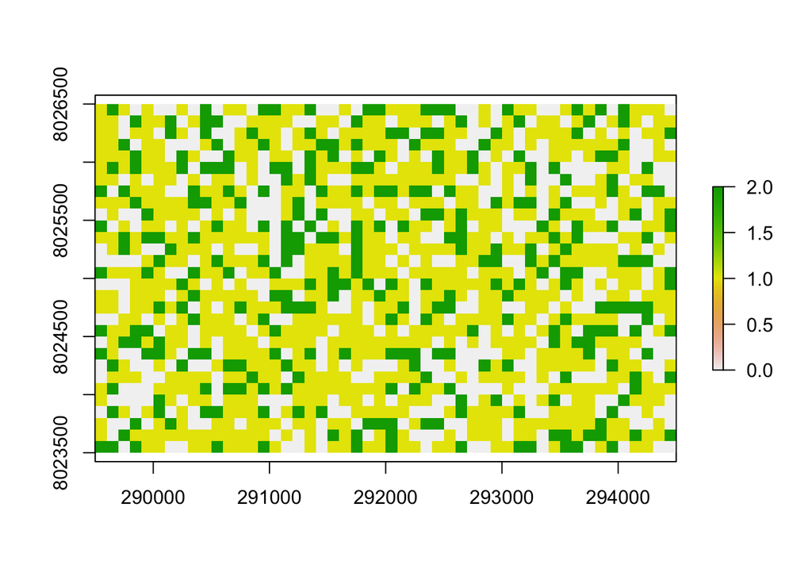

```r
land <- simple.land(x.extent=5000, y.extent=3000, res=c(100,100), prop.forest=0.2, prop.grass=0.5)
plot(land)
```

That certainly isn’t the most realistic landscape I have ever seen, but we made a surface that could theoretically dicatate an animal’s movements. What is it exactly that makes it look so unrealistic, though? We have seen rasterized surfaced before, so it’s not the fact that we have little boxes. Perhaps the issue is that we normally think about landscapes with some level of autocorrealtion. Here, we have completely randomly chosen the state of each of the vegetation types. We were able to define the relative proportion of each, but we know that where we have some forest in the real world, we are more likley to have other forest nearby. In other words, landscapes don’t abide by completely random processes in most cases. Rather, they tend to exhibit patterns whereby like are located near like.

There are a number of alternative ways to include autocorrelation when simulating a landscape. Take a few minutes to think about some possible ways to do this. Feel free to build a function that results in a landscape that isn’t quite as random as the output of `simple.land`. If it is easier, you can also shift from a three-class vegetation layer to a more continuous variable ranging from 0 to 10 that could represent something like NDVI.

After you’ve taken some time to work on the problem yourselves, we will discuss a relatively straightforward approach that incorporates some autocorrelation.

*** Don’t read beyond here until you’ve considered your own approach to the problem ***

I’m going to make a few adjustments this time. Rather than begninning with the size and resolution of the raster we want to create, we are going to input a SpatialPolygons object of our landscape and then define only the resolution. The user will also input the probability of a high quality cell (these will have values drawn from their own distribution) and the mean cell quality (for cells not within the radius of influence of the high quality cells). I am going to use the `truncnorm::rtruncnorm` function to make sure that our selected values do not go below 0 or above 10.

```r
library(truncnorm)
library(rgeos)
autocorr.land <- function(site.poly, res, prop.high, mean.cell.qual) {

  site.extent <- extent(site.poly)
  r <- raster(site.extent)
  res(r) <- res
  projection(r) <- CRS("+proj=utm +south +zone=35 +ellps=WGS84")
  r[] <- 0
  cell.size <- res[1]
  grid <- data.frame(coordinates(r)[!is.na(values(r)),])
  grid <- SpatialPoints(grid, proj4string = CRS("+proj=utm +south +zone=35 +ellps=WGS84"))

  # Randomly assign values for quality of browse
  veg <- data.frame(matrix(0,length(r@data@values),3))
  for (i in 1:nrow(veg)) {
    veg[i,1] <- i
    veg[i,2] <- rbinom(1,1,prop.high) #whether this is a max cell or not
    veg[i,3] <- rtruncnorm(n=1, mean=mean.cell.qual, sd=(mean.cell.qual/4), a=0)
  }

  for (k in 1:nrow(veg)) {
    if (veg[k,2] == 1) {
      id <- veg[k,1]
      pos <- SpatialPoints(grid[id,], proj4string = CRS("+proj=utm +south +zone=35 +ellps=WGS84"))
      quality.radius <- cell.size*abs(rnorm(1,3,1))
      nearby <- gBuffer(pos, width=quality.radius, byid=TRUE)
      within <- which(over(grid,nearby) == TRUE)
      for (j in 1:length(within)) {
        id2 <- within[j]
        veg[id2,3] <- rtruncnorm(n=1, mean=(2*(mean.cell.qual)), sd=(mean.cell.qual/4), b=10)
      }
    }
  }

  colnames(veg) <- c("cell_ID", "High_binom", "NDVI")
  r@data@values <- veg$NDVI

  return(r)
}
```

Let’s see what we get now! Remember, we’re going to need to create a nice little polygon object of our site to start the process off. We can just steal a few lines from our function above to get an idea of what we need:

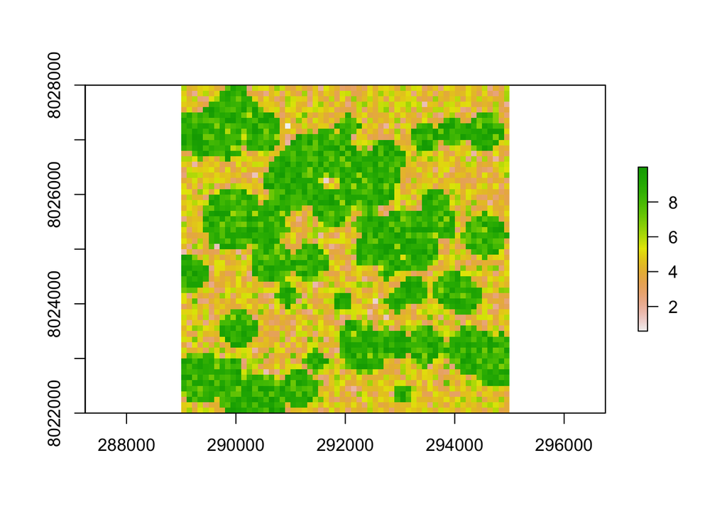

```r
site <- data.frame(matrix(c(-3000, 3000, 3000, -3000, 3000, 3000, -3000, -3000),4,2))

for (i in 1:nrow(site)) {
  site[i,1] <- site[i,1] + 292000
  site[i,2] <- site[i,2] + 8025000
}
site <- SpatialPoints(site, proj4string=CRS("+proj=utm +south +zone=35 +ellps=WGS84"))

poly <- Polygon(site)
ps <- Polygons(list(poly),1)
site.poly <- SpatialPolygons(list(ps))

land2 <- autocorr.land(site.poly, res=c(100,100), prop.high=0.02, mean.cell.qual=4.5)
plot(land2)
```

Now that looks a bit more like a real landscape! We can see that high quality cells tend to be clumped with other high quality cells, and the rest of the matrix is relatively lower quality. You’ll notice that the shapes of these high quality areas are somewhat circular. That may not reflect reality precisely, but at a broad scale, the circles combine in some interesting shapes that aren’t quite circular. Of course, this is a function of the fact that we used a radius around a few cells that we defined as high quality. There is some level of randomness to the size of the radius, so the circles look less uniform and approach something like reality.

So what can we do with that cool landscape we’ve created? Let’s place an agent on the landscape and have its movements determined by the quality of the cells. We can see this interaction in multiple different ways, but let’s just use a two-state model and say that whenever the animal is in state 2, its angle shifts so that it heads towards the highest quality cell nearby. This term ‘nearby’ though, needs to be defined before we do anything else. This is where an agent-based model gets some of its value; we can set a separate ‘perceptual radius’ for each agent and maintain that value throughout the simulation. We could even change it if we wanted (but we won’t in this case).

So, we’ll need a few things here: 1. We are going to want to set up a data frame that contains the information we need on our agents (i.e., perceptual range). If we wanted, we could also include variables like species ID, which might serve to guide our selection of the perceptual range value. In this case, we will assume that the proportions of the different species are approximately equivalent. 2. We need to assign initial positions to each of the agents, which we can store in the form of a list of data frames (i.e., data frame with nrow = number of steps and a list with length = number of agents) 3. We will want to develop a function that allows us to calculate the angle between the current position of the agent and the highest quality cell within its perceptual range 4. Because of our dependence on the landscape, we are going to need to make sure that all of the points fall within our landscape (as if there were a fence around it) using a `bounce` function 5. Finally, we will need a function (similar to our `multi.state` function) that has two sets of step lengths.

```r
library(prevR)
initialize.agents <- function(N, num.sp, percep.means) {
  agents <- data.frame(matrix(0,N,4))
  for (i in 1:N) {
    agents[i,1] <- i
    rand <- runif(1,0,1)
    if (rand < (1/num.sp)) {
      agents[i,2] <- 1
    } else {
      agents[i,2] <- 2
    }
    agents[i,3] <- rnorm(1, mean=percep.means[agents[i,2]], sd=(percep.means[agents[i,2]]/4))
    agents[i,4] <- rbinom(n=1, size=1, prob=0.7)
  }
  colnames(agents) <- c("ID", "species", "percep.range", "behav.state")
  return(agents)
}

initialize.positions <- function(agents, site.poly) {
  steps.list <- list()
  start.pts <- spsample(site.poly, nrow(agents), type='random')

  for (i in 1:nrow(agents)) {
    steps.df <- data.frame(matrix(0,1,5))
    steps.df[1,1] <- start.pts@coords[i,1]
    steps.df[1,2] <- start.pts@coords[i,2]
    steps.df[1,5] <- agents$behav.state[i]
    steps.list[[i]] <- steps.df
  }
  return(steps.list)
}

angle.func <- function(coords1, coords2) {
  #Determine the difference in the x coords and y coords
  xx <- coords2[1,1] - coords1[1,1]
  yy <- coords2[1,2] - coords1[1,2]

  b <- sign(yy)
  b[b == 0] <- 1  #corrects for the fact that sign(0) == 0
  #Use arctan to determine the absolute angle based on two values from above
  temp.angle <- b*(xx < 0) * pi + atan(yy/xx)
  return(temp.angle)
}

movement <- function(xy, step, heading) {

  #First we need to define pi
  pi = 3.141593

  #Then we split the starting point into an x_init and y_init
  x_init <- xy[1,1]
  y_init <- xy[1,2]

  #Here we translate the negative pi values into positive values
  #The headings now range from 0 to 2*pi
  if (heading < 0) {
    heading <- abs(heading) + pi
  }

  #Using this heading, and our sin function, we can solve for the change in y
  #Then we want to create a new value where we alter the starting y value
  y_change <- sin(heading)*step
  y_new <- y_init + y_change

  #The use cosine to determine the movement in x direction
  x_change <- cos(heading)*step
  x_new <- x_init + x_change

  #Finally, we create a data frame and save our new coordinates
  move.temp <- as.data.frame(matrix(0,1,4))
  move.temp[1,1] <- x_new
  move.temp[1,2] <- y_new
  move.temp[1,3] <- step
  move.temp[1,4] <- heading

  return(move.temp)
}

bounce <- function(pos, move, region, step.params) {
  while (point.in.SpatialPolygons(move[1,1], move[1,2], region) == FALSE) {
      old.pts <- pos
      new.step <- (1.5 * (step.params[1,2]))
      old.heading <- move[1,4]
      if ((old.heading + pi) > (2*pi)) {
        heading <- (old.heading - pi)
      } else {
        heading <- (old.heading + pi)
      }
      move[,1:4] <- movement(pos, new.step, heading)
  }
  return(move)
}

move.percep <- function(agents, steps.list, site.poly, land, step.params, n.steps) {
  grid <- data.frame(coordinates(land)[!is.na(values(land)),])
  grid <- SpatialPoints(grid, proj4string = CRS("+proj=utm +south +zone=35 +ellps=WGS84"))

  for (k in 2:n.steps) {
    for (i in 1:nrow(agents)) {
      pos <- steps.list[[i]][nrow(steps.list[[i]]),1:2]
      steps.df <- data.frame(steps.list[[i]])
      # Evaluate the current state of the agent, those in state 2 (i.e., behav.state = 1) will search for high quality cells
      if (agents$behav.state[i] == 1) {
        # Use the perceptual range value to extract all raster cell values within the buffer
        percep.range <- agents$percep.range[i]
        cell.vals <- data.frame(extract(x=land, y=SpatialPoints(pos, CRS("+proj=utm +south +zone=35 +ellps=WGS84")), buffer=percep.range, cellnumbers=TRUE))
        # Determine which of those cells is the maximum and set the coordinates of its center as the destination of our agent
        max.quality <- which.max(cell.vals$value)
        id <- cell.vals[max.quality,1]
        max.coords <- grid[id,]
        # Use the angle.func to determine the heading between the current position and the destination cell
        heading <- angle.func(data.frame(coordinates(pos)), data.frame(coordinates(max.coords@coords)))
        step.length <- rgamma(n=1, shape=((step.params[1,1]^2)/(step.params[2,1]^2)), rate=(step.params[1,1]/(step.params[2,1]^2)))
      } else {
        heading <- runif(1,0,2*pi)
        step.length <- rgamma(n=1, shape=((step.params[1,2]^2)/(step.params[2,2]^2)), rate=(step.params[1,2]/(step.params[2,2]^2)))
      }
      # Plug our values into the old movement function (which is pasted again above)
      next.pt <- movement(steps.df[(k-1),1:2], step.length, heading)
      # Make sure the new point is within our polygon; if not, replace
      next.pt <- bounce(pos, next.pt, site.poly, step.params)
      # Add new location information into steps.list
      steps.df[k,1:4] <- next.pt
      steps.df[k,5] <- agents$behav.state[i]
      steps.list[[i]] <- steps.df
      # Now arbitrarily re-assign the agent to a new behavioral state
      agents$behav.state[i] <- rbinom(n=1, size=1, prob=0.7)
    }
  }
  # It may be helpful to create a list of any thing that may change throughout the function; we know the steps.list changes, and so does the agent's behavioral state, so we'll save both as outputs (which must come in the form of a list)
  move.list <- list(agents, steps.list)
  return(move.list)
}
```

```r
step.params <- matrix(c(55.610, 101.017, 332.775, 578.086), ncol=2)

agents <- initialize.agents(N=20, num.sp=2, percep.means=c(250,400))
steps.list <- initialize.positions(agents, site.poly)
moves.list <- move.percep(agents, steps.list, site.poly, land2, step.params, 20)
# Here we can separate the elements of our moves.list object into the agent data frame and the steps.list
agents <- moves.list[[1]]
steps.list <- moves.list[[2]]
```

Now that we have extracted the `steps.list`, we can find one of the agents that should generally be exploring the space in search of the highest quality cells and see how its doing:

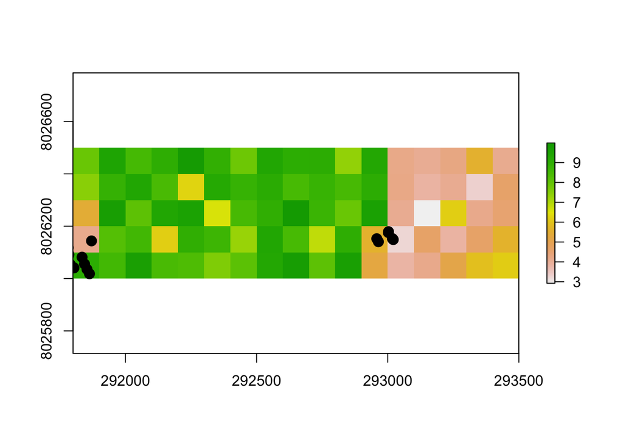

```r
agent1.pts <- SpatialPoints(steps.list[[1]][,1:2], proj4string = CRS("+proj=utm +south +zone=35 +ellps=WGS84"))
bounding.box <- agent1.pts@bbox
plot(land2, xlim=c(bounding.box[1,1], bounding.box[1,2]), ylim=c(bounding.box[2,1], bounding.box[2,2]))
points(agent1.pts, pch=19, cex=1.5)
```

It looks like the animal did find the highest quality cell in that small area and spent some time there, presumably while he was in the foraging state.

If we were feeling ambitious, we could add an additional variable to the agent data frame that defines its hunger level and have that dictate the shift between the states. In order to do this, we’ll have to remake our agent data frame with an additional variable (hunger) which we can have range between 0 and 1. We’ll say that an animal with a hunger level above 0.5 will switch to a foraging state (1), and will eat when it is in a high quality cell (i.e., above 7). When it is not eating, it gains 0.1 hunger units, and when it eats, it loses 0.15 hunger units.

```r
initialize.agents2 <- function(N, num.sp, percep.means) {
  agents <- data.frame(matrix(0,N,5))
  for (i in 1:N) {
    agents[i,1] <- i
    rand <- runif(1,0,1)
    if (rand < (1/num.sp)) {
      agents[i,2] <- 1
    } else {
      agents[i,2] <- 2
    }
    agents[i,3] <- rnorm(1, mean=percep.means[agents[i,2]], sd=(percep.means[agents[i,2]]/4))
    agents[i,5] <- runif(1,0,1)
    if (agents[i,5] > 0.5) {
      agents[i,4] <- 1
    } else {
      agents[i,4] <- 0
    }
  }
  colnames(agents) <- c("ID", "species", "percep.range", "behav.state", "hunger")
  return(agents)
}

initialize.positions2 <- function(agents, site.poly) {
  steps.list <- list()
  start.pts <- spsample(site.poly, nrow(agents), type='random')

  for (i in 1:nrow(agents)) {
    steps.df <- data.frame(matrix(0,1,5))
    steps.df[1,1] <- start.pts@coords[i,1]
    steps.df[1,2] <- start.pts@coords[i,2]
    steps.df[1,5] <- agents$behav.state[i]
    steps.df[1,6] <- agents$hunger[i]
    steps.list[[i]] <- steps.df
  }
  return(steps.list)
}

feeding <- function(agents, hunger.level, pos, land) {
  curr.cell <- extract(land, pos)
  if (agents$behav.state[i] == 1 && curr.cell > 7) {
    hunger.level <- (hunger.level - 0.15)
  } else if ((hunger.level + 0.1) < 1) {
    hunger.level <- (hunger.level + 0.1)
  } else {
    hunger.level <- 1
  }
  return(hunger.level)
}

move.feeding <- function(agents, steps.list, site.poly, land, step.params, n.steps) {
  grid <- data.frame(coordinates(land)[!is.na(values(land)),])
  grid <- SpatialPoints(grid, proj4string = CRS("+proj=utm +south +zone=35 +ellps=WGS84"))

  for (k in 2:n.steps) {
    for (i in 1:nrow(agents)) {
      pos <- steps.list[[i]][nrow(steps.list[[i]]),1:2]
      steps.df <- data.frame(steps.list[[i]])
      # Evaluate the current state of the agent, those in state 2 (i.e., behav.state = 1) will search for high quality cells
      if (agents$behav.state[i] == 1) {
        # Use the perceptual range value to extract all raster cell values within the buffer
        percep.range <- agents$percep.range[i]
        cell.vals <- data.frame(extract(x=land, y=SpatialPoints(pos, CRS("+proj=utm +south +zone=35 +ellps=WGS84")), buffer=percep.range, cellnumbers=TRUE))
        # Determine which of those cells is the maximum and set the coordinates of its center as the destination of our agent
        max.quality <- which.max(cell.vals$value)
        id <- cell.vals[max.quality,1]
        max.coords <- grid[id,]
        # Use the angle.func to determine the heading between the current position and the destination cell
        heading <- angle.func(data.frame(coordinates(pos)), data.frame(coordinates(max.coords@coords)))
        step.length <- rgamma(n=1, shape=((step.params[1,1]^2)/(step.params[2,1]^2)), rate=(step.params[1,1]/(step.params[2,1]^2)))
      } else {
        heading <- runif(1,0,2*pi)
        step.length <- rgamma(n=1, shape=((step.params[1,2]^2)/(step.params[2,2]^2)), rate=(step.params[1,2]/(step.params[2,2]^2)))
      }
      # Plug our values into the old movement function (which is pasted again above)
      next.pt <- movement(steps.df[(k-1),1:2], step.length, heading)
      # Make sure the new point is within our polygon; if not, replace
      next.pt <- bounce(pos, next.pt, site.poly, step.params)
      # Determine the current hunger level and implement the feeding function above
      hunger.level <- agents$hunger[i]
      agents$hunger[i] <- feeding(agents, hunger.level, next.pt[,1:2], land)
      # Add new location information into steps.list
      steps.df[k,1:4] <- next.pt
      steps.df[k,6] <- agents$hunger[i]
      # Now re-assign the agent to a new behavioral state based on hunger level
      if (agents$hunger[i] > 0.5) {
        agents$behav.state[i] <- 1
      } else {
        agents$behav.state[i] <- 0
      }
      steps.df[k,5] <- agents$behav.state[i]
      steps.list[[i]] <- steps.df

    }
  }
  # It may be helpful to create a list of any thing that may change throughout the function; we know the steps.list changes, and so does the agent's behavioral state, so we'll save both as outputs (which must come in the form of a list)
  move.list <- list(agents, steps.list)
  return(move.list)
}
```

Now let’s test out our more complex function:

```r
agents2 <- initialize.agents2(N=20, num.sp=2, percep.means=c(250,400))
steps.list2 <- initialize.positions2(agents2, site.poly)
moves.list2 <- move.feeding(agents2, steps.list2, site.poly, land2, step.params, 20)
agents2 <- moves.list2[[1]]
steps.list2 <- moves.list2[[2]]
```

Now, if we take a look at one of these individuals and note their behavioral state (fifth column) and their hunger level (sixth column), we should see an interaction whereby the animal is in the foraging state if their hunger level is at least 0.5, and until they find some food and reduce their hunger, they remain in the foraging state.

```r
steps.list2[[1]]
```

```
##          X1      X2           X3       X4 X5        V6
## 1  294197.0 8024470   0.00000000 0.000000  1 0.7230597
## 2  294181.1 8024478  18.16175470 2.641039  1 0.5730597
## 3  294174.0 8024482   8.04274793 2.641039  1 0.6730597
## 4  294173.8 8024482   0.30157710 2.641039  1 0.7730597
## 5  294156.2 8024492  19.96799216 2.641039  1 0.6230597
## 6  294054.4 8024548 116.06874651 2.641039  1 0.7230597
## 7  294054.3 8024548   0.17452496 2.641039  1 0.5730597
## 8  294054.2 8024548   0.06196841 2.641039  1 0.6730597
## 9  294019.1 8024567  39.99085487 2.641039  1 0.7730597
## 10 294013.6 8024564   6.26379608 3.642146  1 0.6230597
## 11 293608.5 8024409 433.65710248 3.506242  1 0.7230597
## 12 293660.5 8024397  53.35898226 6.057925  1 0.5730597
## 13 293731.8 8024347  87.05770766 5.672568  0 0.4230597
## 14 293822.0 8024299 102.17548967 5.793507  1 0.5230597
## 15 293862.3 8024160 145.43817997 4.993471  0 0.3730597
## 16 293861.1 8024161   1.71074028 2.371177  0 0.4730597
## 17 293800.0 8024053 123.81942177 4.196467  0 0.3230597
## 18 292949.5 8023754 901.45240050 3.479367  0 0.4230597
## 19 293116.5 8023545 267.54230902 5.386548  1 0.5230597
## 20 293162.2 8023480  79.84831720 5.321492  1 0.6230597
```

There you have it! You’ve now built a fairly complex little agent based model where simulated individuals move across a simulated landscape and directly interact with it! One further step would be to have the feeding process reflected in the quality of the cells in the landscape, but I’ll let you tackle that challenge on your own.